# Deliverable 1

Madeline Hoshko

October 4, 2019

I first bring in my dataset and set all empty data to NA. I then format my date column to be of type date and derive a Year column for potential use in visualizations. Additionally, I created a new column of data for the number of drugs within the person’s system at the time of death, currently set to 0. By setting the number of drugs to 0, this will ease the process of adding 1 for each column variable that was present. I include the head of my dataframe as a reference to changes made afterwards.

```r
df <- read.csv('Drug Death Data.csv', na.strings=c("","NA"))
head(df)
```

|  | ID | Date | DateType | Age | Sex | Race | ResidenceCity | ResidenceCounty | ResidenceState | DeathCity | DeathCounty | Location | LocationifOther | DescriptionofInjury | InjuryPlace | InjuryCity | InjuryCounty | InjuryState | COD | OtherSignifican | Heroin | Cocaine | Fentanyl | FentanylAnalogue | Oxycodone | Oxymorphone | Ethanol | Hydrocodone | Benzodiazepine | … |
| --- | --- | --- | --- | --- | --- | --- | --- | --- | --- | --- | --- | --- | --- | --- | --- | --- | --- | --- | --- | --- | --- | --- | --- | --- | --- | --- | --- | --- | --- | --- |
| 1 | 14-0273 | 06/28/2014 12:00:00 AM | DateReported | NA | NA | NA | NA | NA | NA | NA | NA | NA | NA | substance | NA | NA | NA | NA | Acute fent, hydrocod, benzodiazepine | NA | NA | NA | Y | NA | NA | NA | NA | Y | Y | … |
| 2 | 13-0102 | 03/21/2013 12:00:00 AM | DateofDeath | 48 | Male | Black | NORWALK | NA | NA | NORWALK | FAIRFIELD | Hospital | NA | NA | NA | NA | NA | NA | Cocaine Intoxication | NA | NA | Y | NA | NA | NA | NA | NA | NA | NA | … |
| 3 | 16-0165 | 03/13/2016 12:00:00 AM | DateofDeath | 30 | Female | White | SANDY HOOK | FAIRFIELD | CT | DANBURY | NA | Hospital | NA | Substance Abuse | Unknown | UNKNOWN | NA | NA | Acute Heroin and Cocaine Intoxication | NA | Y | Y | NA | NA | NA | NA | NA | NA | NA | … |
| 4 | 16-0208 | 03/31/2016 12:00:00 AM | DateofDeath | 23 | Male | White | RYE | WESTCHESTER | NY | GREENWICH | NA | Hospital | NA | substance abuse | Residence | RYE | NA | NA | Acute Fentanyl and Morphine Intoxication | NA | Y | NA | Y | NA | NA | NA | NA | NA | NA | … |
| 5 | 13-0052 | 02/13/2013 12:00:00 AM | DateofDeath | 22 | Male | Asian, Other | FLUSHING | QUEENS | NA | GREENWICH | FAIRFIELD | Hospital | NA | Transdermal Absorption | Other | NA | NA | NA | Fentanyl Intoxication | NA | NA | NA | Y | NA | NA | NA | NA | NA | NA | … |
| 6 | 14-0277 | 06/29/2014 12:00:00 AM | DateofDeath | 23 | Male | White | BRISTOL | NA | NA | BRISTOL | HARTFORD | Residence | NA | Inhalation | Residence | NA | NA | NA | Heroin Intoxication | NA | Y | NA | NA | NA | NA | NA | NA | NA | NA | … |

```r
df <- select(df, -"ID")

df$Date <- gsub( " .*$", "", df$Date )
df$Date <- as.Date(df$Date, format="%m/%d/%Y")
df$Year <- year(df$Date)

df$numberOfDrugs <- 0
```

I now rename columns to reduce confusion, as well as change all “Geo” columns to only include their coordinate data to reduce redundancy of city and county names amongst the data. Then I set columns to be factors where necessary.

```r
#renaming columns
colnames(df)[colnames(df)=="COD"] <- "CauseOfDeath"
colnames(df)[colnames(df)=="DeathCityGeo"]<-"DeathCityCoordinates"
colnames(df)[colnames(df)=="ResidenceCityGeo"]<-"ResidenceCityCoordinates"
colnames(df)[colnames(df)=="InjuryCityGeo"]<-"InjuryCityCoordinates"

#formatting latitude/longitude columns
df$DeathCityCoordinates <- gsub(".*\\n", "", df$DeathCityCoordinates)
df$ResidenceCityCoordinates <- gsub(".*\\n", "", df$ResidenceCityCoordinates)
df$InjuryCityCoordinates <- gsub(".*\\n", "", df$InjuryCityCoordinates)


#Setting columns to factors
df$Location <- as.factor(df$Location)
df$MannerofDeath <- tolower(df$MannerofDeath)
df$MannerofDeath <- factor(df$MannerofDeath)
df$DeathCity <- as.character.factor(df$DeathCity)
df$InjuryCity <- as.character.factor(df$InjuryCity)
df$ResidenceCity <- as.character.factor(df$ResidenceCity)
df$DeathCounty <- as.character.factor(df$DeathCounty)
df$InjuryCounty <- as.character.factor(df$InjuryCounty)
df$ResidenceCounty <- as.character.factor(df$ResidenceCounty)
df$InjuryState <- as.character.factor(df$InjuryState)
df$ResidenceState <- as.character.factor(df$ResidenceState)
df$DeathCounty[df$DeathCounty=="USA"] <- NA
```

I now substitute all NA values over the columns indicating whether the specific drug was found in the person’s system at time of death with “N” to match the format “Y” for when it is true. I also increase the number of drugs for the observation whenever one of the columns is labeled “Y”. I repeat through all columns (Heroin, Cocaine, Fentanyl, FentanylAnalogue, Oxycodone, Oxymorphone, Ethanol, Hydrocodone, Benzodiazepine, Methadone, Amphet, Tramad, Morphine_NotHeroine, Hydromorphone, Other, AnyOpioid, and OpiateNOS), but only show the first column code to reduce clutter within this file.

```r
df$numberOfDrugs <- ifelse(is.na(df$OtherSignifican), df$numberOfDrugs+0, df$numberOfDrugs+1)
df$OtherSignifican <- ifelse(is.na(df$OtherSignifican), "N", "Y")
```

Included here is the head of my dataframe to prove changes have been made to clean up the data in previous steps.

```r
head(df)
```

|  | Date | DateType | Age | Sex | Race | ResidenceCity | ResidenceCounty | ResidenceState | DeathCity | DeathCounty | Location | LocationifOther | DescriptionofInjury | InjuryPlace | InjuryCity | InjuryCounty | InjuryState | CauseOfDeath | OtherSignifican | Heroin | Cocaine | Fentanyl | FentanylAnalogue | Oxycodone | Oxymorphone | Ethanol | Hydrocodone | Benzodiazepine | Methadone | … |
| --- | --- | --- | --- | --- | --- | --- | --- | --- | --- | --- | --- | --- | --- | --- | --- | --- | --- | --- | --- | --- | --- | --- | --- | --- | --- | --- | --- | --- | --- | --- |
| 1 | 2014-06-28 | DateReported | NA | NA | NA | NA | NA | NA | NA | NA | NA | NA | substance | NA | NA | NA | NA | Acute fent, hydrocod, benzodiazepine | N | N | N | Y | N | N | N | N | Y | Y | N | … |
| 2 | 2013-03-21 | DateofDeath | 48 | Male | Black | NORWALK | NA | NA | NORWALK | FAIRFIELD | Hospital | NA | NA | NA | NA | NA | NA | Cocaine Intoxication | N | N | Y | N | N | N | N | N | N | N | N | … |
| 3 | 2016-03-13 | DateofDeath | 30 | Female | White | SANDY HOOK | FAIRFIELD | CT | DANBURY | NA | Hospital | NA | Substance Abuse | Unknown | UNKNOWN | NA | NA | Acute Heroin and Cocaine Intoxication | N | Y | Y | N | N | N | N | N | N | N | N | … |
| 4 | 2016-03-31 | DateofDeath | 23 | Male | White | RYE | WESTCHESTER | NY | GREENWICH | NA | Hospital | NA | substance abuse | Residence | RYE | NA | NA | Acute Fentanyl and Morphine Intoxication | N | Y | N | Y | N | N | N | N | N | N | N | … |
| 5 | 2013-02-13 | DateofDeath | 22 | Male | Asian, Other | FLUSHING | QUEENS | NA | GREENWICH | FAIRFIELD | Hospital | NA | Transdermal Absorption | Other | NA | NA | NA | Fentanyl Intoxication | N | N | N | Y | N | N | N | N | N | N | N | … |
| 6 | 2014-06-29 | DateofDeath | 23 | Male | White | BRISTOL | NA | NA | BRISTOL | HARTFORD | Residence | NA | Inhalation | Residence | NA | NA | NA | Heroin Intoxication | N | Y | N | N | N | N | N | N | N | N | N | … |

I now include visualizations to the drug overdose deaths, each explained within its graph title. I use filtering to promote cleaner data and reduce outliers throughout (mostly in terms of eliminated NA’s). I left these values in currently to refrain from eliminating data I may want to use in the future.

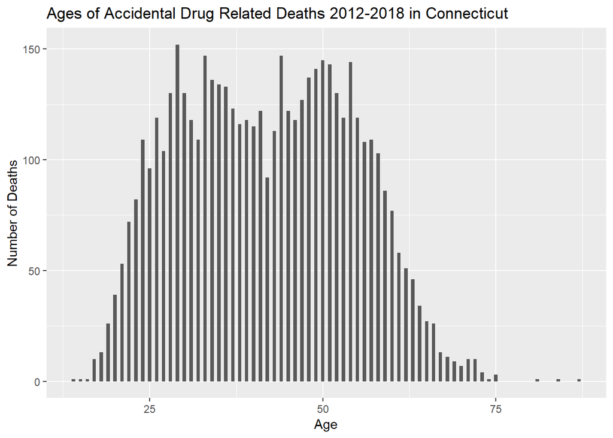

```r
filter(df, !is.na(Age)) %>%
  ggplot(aes(x=Age)) +
  geom_histogram(binwidth = .5) +
  labs(title='Ages of Accidental Drug Related Deaths 2012-2018 in Connecticut', x='Age', y='Number of Deaths')
```

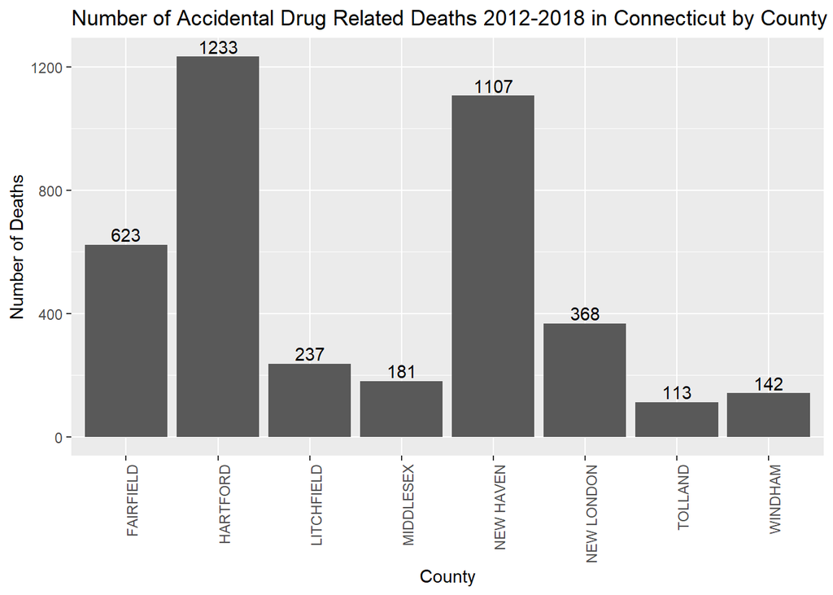

```r
filter(df, !is.na(DeathCounty)) %>%
  ggplot(aes(x=DeathCounty)) +
  geom_bar(stat="count") +
  labs(title='Number of Accidental Drug Related Deaths 2012-2018 in Connecticut by County', x='County', y='Number of Deaths') +
  theme(axis.text.x=element_text(angle=90, hjust=1)) +
  geom_text(stat='count', aes(label=..count..), position=position_dodge(width=0.9), vjust=-0.25)
```

Within the dataset, 2016 and some of 2014 do not have location data for the death county, so I will be working towards deriving this information from those that do include death city with another dataset that links cities to counties for Connecticut in the next deliverable.

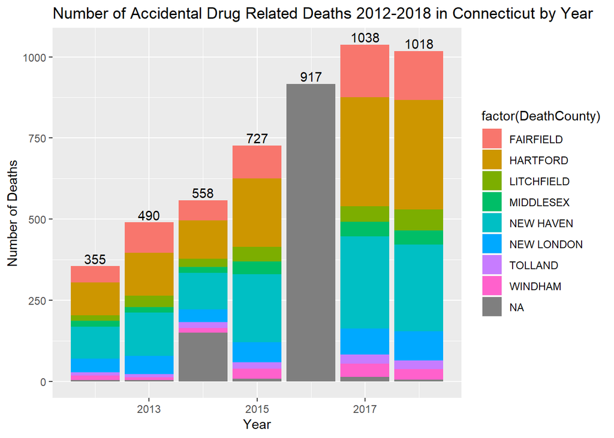

```r
filter(df, !is.na(Year)) %>%
  ggplot(aes(x=Year, y=..count..))+
  geom_bar(aes(fill=factor(DeathCounty))) +
  labs(title='Number of Accidental Drug Related Deaths 2012-2018 in Connecticut by Year', x='Year', y='Number of Deaths') +
  geom_text(stat='count', aes(label=..count..), position=position_dodge(width=0.9), vjust=-0.25)
```

```r
df %>%
   filter(!is.na(Fentanyl)) %>%
   filter(!is.na(Year))%>%
   group_by(Year) %>%
   summarise(Sum_of_Fentanyl_Deaths=n())
```

| Year | Sum_of_Fentanyl_Deaths |
| --- | --- |
| 2012 | 355 |
| 2013 | 490 |
| 2014 | 558 |
| 2015 | 727 |
| 2016 | 917 |
| 2017 | 1038 |
| 2018 | 1018 |

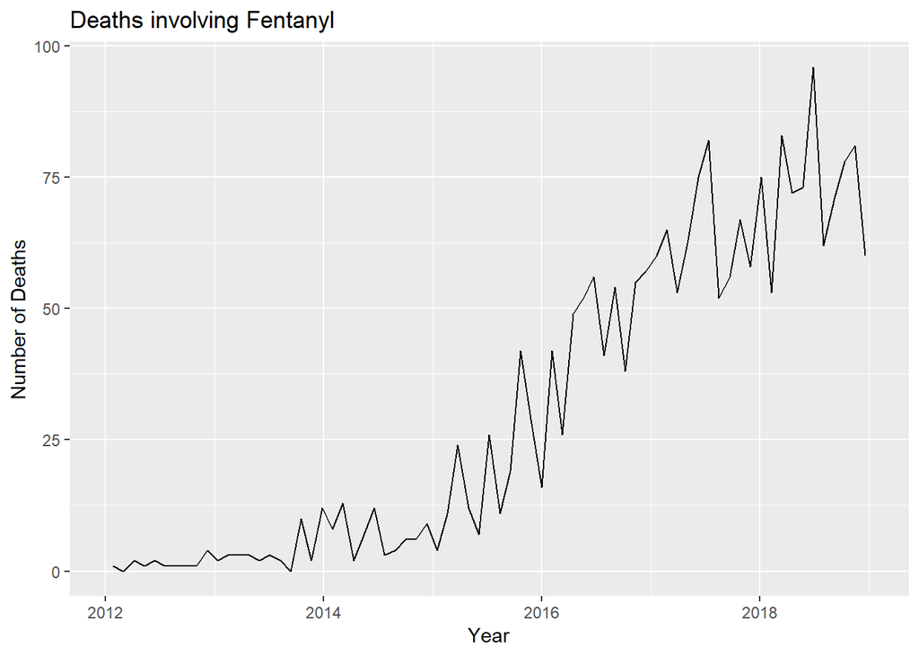

```r
df %>%
  filter(Fentanyl=="Y") %>%
  filter(!is.na(Year)) %>%
  ggplot(aes(x=Date))+ geom_line(aes(y=..count..), stat="bin", binwidth=35)+
  labs(title="Deaths involving Fentanyl", x="Year", y="Number of Deaths")
```

```r
df %>%
   filter(!is.na(Fentanyl)) %>%
   filter(!is.na(Year))%>%
   group_by(Year) %>%
   summarise(Sum_of_Non_Fentanyl_Deaths=n())
```

| Year | Sum_of_Non_Fentanyl_Deaths |
| --- | --- |
| 2012 | 355 |
| 2013 | 490 |
| 2014 | 558 |
| 2015 | 727 |
| 2016 | 917 |
| 2017 | 1038 |
| 2018 | 1018 |

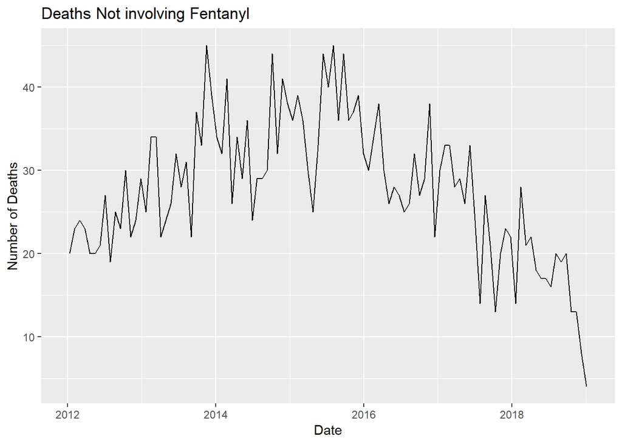

```r
df %>%
  filter(Fentanyl=="N") %>%
  filter(!is.na(Year)) %>%
  ggplot(aes(x=Date))+ geom_line(aes(y=..count..), stat="bin", binwidth=25) +
  labs(title="Deaths Not involving Fentanyl", x="Date", y="Number of Deaths")
```

```r
df %>%
   filter(!is.na(Age)) %>%
   filter(!is.na(Year)) %>%
   group_by(Year) %>%
   summarise(Mean_Age = mean(Age))
```

| Year | Mean_Age |
| --- | --- |
| 2012 | 40.77183 |
| 2013 | 41.38776 |
| 2014 | 41.57810 |
| 2015 | 42.30303 |
| 2016 | 42.08288 |
| 2017 | 41.74085 |
| 2018 | 42.76523 |

```r
df %>%
  filter(!is.na(numberOfDrugs)) %>%
  filter(!is.na(Year)) %>%
  group_by(Year) %>%
  summarise(Mean_Number_of_Drugs = mean(numberOfDrugs))
```

| Year | Mean_Number_of_Drugs |
| --- | --- |
| 2012 | 1.794366 |
| 2013 | 1.667347 |
| 2014 | 2.059140 |
| 2015 | 3.013755 |
| 2016 | 3.252999 |
| 2017 | 2.550096 |
| 2018 | 3.590373 |

```r
df %>%
  filter(!is.na(numberOfDrugs)) %>%
  filter(!is.na(Year)) %>%
  filter(!is.na(Sex)) %>%
  group_by(Year) %>%
  group_by(Sex) %>%
  summarise(num_deaths = n())
```

| Sex | num_deaths |
| --- | --- |
| Female | 1325 |
| Male | 3772 |
| Unknown | 1 |

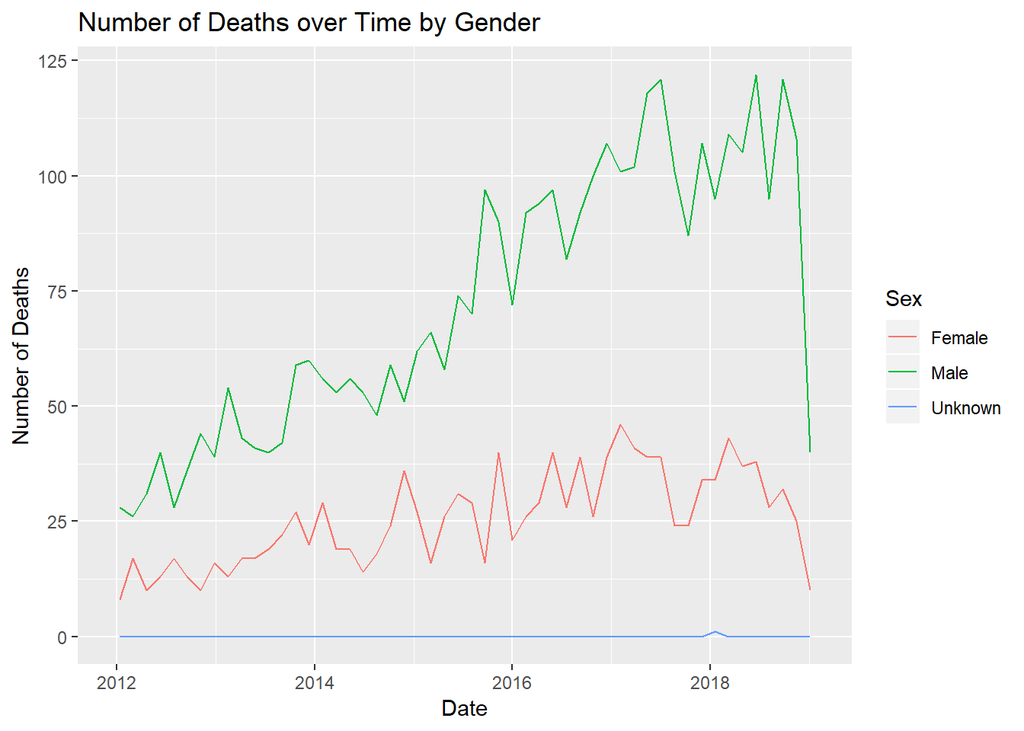

```r
filter(df, !is.na(Date)) %>%
  filter(!is.na(Sex)) %>%
  ggplot(aes(x=Date)) + geom_line(aes(y=..count.., color=Sex), stat="bin", binwidth=50) +
  labs(title="Number of Deaths over Time by Gender", x="Date", y="Number of Deaths")
```

# Conclusion

The current data shows trends in the increased involvement in Fentanyl in overdoses, as well as an increased number of drugs found in the system of those who overdosed. As there is a lot of missing data within the current dataset, in deliverable two I will incorporate more datasets to fill in much of the missing data to create models and visualizations that accurately depict the overdose problem particular to cities and counties of Connecticut.